# GitHub Copilot

Getting started with AI pair programming

Author

Barry Grant

Published

November 15, 2026

Modified

November 16, 2026

## Overview

[GitHub Copilot](https://docs.github.com/en/copilot) is an AI coding partner or “pair programmer” based on [OpenAI codex](https://chatgpt.com/codex/).

In RStudio it works by analyzing your currently open quarto document (or R script), and the context of what you are currently typing to offer **auto-complete style *“ghost text”* suggestions** (Figure 1).

These suggestions typically include new lines of code or even entire functions that you can accept (with the TAB key), modify, or reject (with the RTN or ESC keys) as you see fit.

[figure not shown]

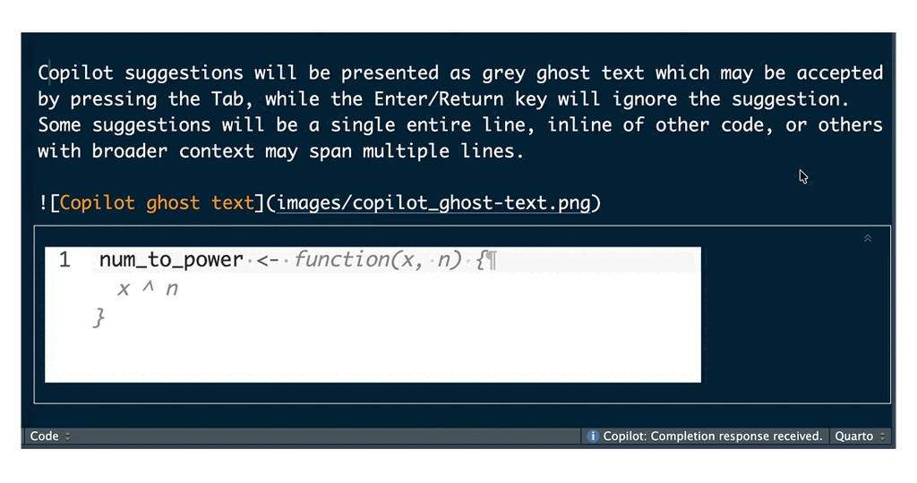

In class we will show you how to integrate GitHub Copilot with RStudio. This is completely optional and not required for any assignment (beyond this lab). However, many students find it tremendously helpful once they have a solid foundation in R programming basics.

## Background

Think of GitHub Copilot as the **navigator** in a *pair-programming* session, with you in the driver’s seat (Figure 2). You as the driver set the goal and decide which AI suggestions to accept, revise, or skip.

Note that while generally useful it can suggest code that looks right and runs without errors while answering the wrong question (we will see an example of this later). Accepting whole AI solutions unchecked can also leave you with code you struggle to explain, debug, or adapt later.

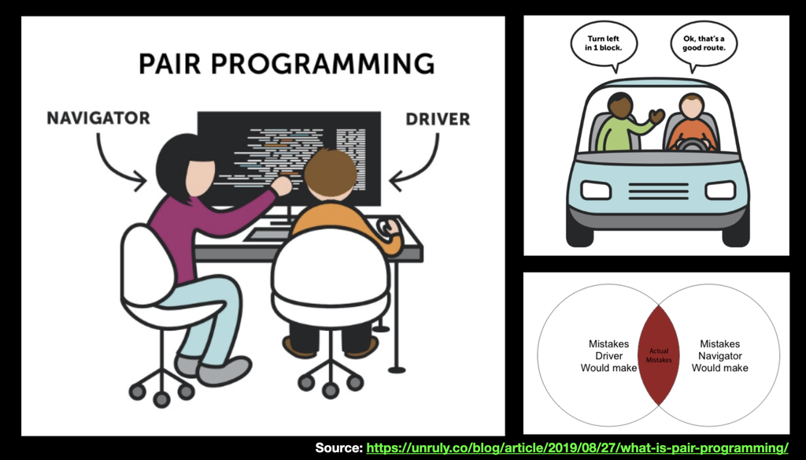

Figure 2: GitHub Copilot is one of several AI powered add-ons available in RStudio that aim to give helpful suggestions when writing code and associated text.

**Important**

**Key-point**: Stay in the driver’s seat. Set the goal, use Copilot to suggest a small next step, and decide what to keep. It is, as always, up to you to test your code and make sure you can explain how it works!

## Learning objectives

By the end of this activity, you should be able to:

- **Setup** and configure GitHub Copilot in RStudio and turn the AI assistant on and off if you choose to use it.
- **Complete** a coding task in R with AI assistance either accepting, rejecting or modifying the AI suggestions.
- **Document** how you used AI assistance, if any, and what you did to verify the result.

## Prerequisites

- To use GitHub Copilot, you must have a GitHub account and an active subscription to Copilot for Individuals or Copilot for Education - which is free for students as part of the GitHub Education program. For more information, see the [GitHub Education page](https://education.github.com/).
- To use GitHub Copilot in RStudio, you must also have a compatible version of RStudio installed (you may need to update your RStudio to one of the latest versions from at least 2025 onwards).
- To use GitHub Copilot, you must have access to the internet in order to send requests to the Copilot APIs and receive suggestions from GitHub Copilot.

## Setup

To enable GitHub Copilot in RStudio:

1. Navigate to Tools > Global Options > Assistant.
2. Select GitHub Copilot from the Use code assistant dropdown.
3. Download and install the Copilot Agent components.
4. Click the Sign In button.
5. In the GitHub Copilot: Sign in dialog, copy the Verification Code.

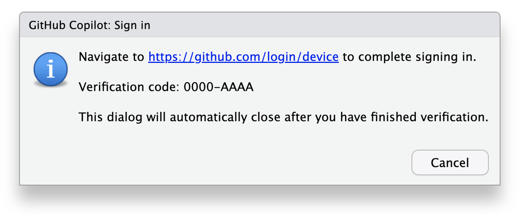

GitHub Copilot: Sign in

6. Navigate to or click on the link to https://github.com/login/device, paste the Verification Code and click Continue.
7. GitHub will request the necessary permissions for GitHub Copilot. To approve these permissions, click Authorize GitHub Copilot Plugin.
8. After the permissions have been approved, your RStudio IDE will indicate the currently signed in user.
9. Close the Global Options dialogue, open a source file (`.R`, `.py`, `.qmd`, etc) and begin coding with Copilot!

## Using Copilot

Copilot offers autocomplete-style suggestions as you code as ghost text. This ghost-text is similar to the existing autocomplete available in RStudio but importantly is a generated suggestion rather than an exact auto-completion.

[figure not shown]

Copilot in RStudio

1. A simple but specific comment providing additional context to Copilot.
2. Copilots code suggestion, shown in light grey ghost text.
3. The Copilot status bar, which indicates whether RStudio is waiting on a response to be generated, a completion response has been received, or no completions are available.

For general advice on how to use Copilot, please see:

- [How to use GitHub Copilot: Prompts, tips, and use cases](https://github.blog/2023-06-20-how-to-write-better-prompts-for-github-copilot/)
- [Learning GitHub Copilot video series](https://learn.microsoft.com/en-us/shows/introduction-to-github-copilot/)

**Warning**

While Copilot often generates useful and functional code, it is important to note that the suggestions are not always valid code examples or completely solve the intended problem. Copilot suggestions are non-deterministic. It is important to review the suggestions and ensure that they are both accurate and appropriate for the intended use case. Copilot may generate code that contains bugs, or outdated practices. You should always use best practices in code review and testing. For more information, see the [FAQs on GitHub Copilot](https://github.com/features/copilot#faq).

### Autocomplete vs Copilot

The existing autocomplete in RStudio is a static list of possible completions based on the session state. Copilot is a dynamic predicted suggestion that is generated based on the document and project context, including comments, code elsewhere in the document or project, and the currently focused characters. Copilot will also provide suggestions for code that is not currently in the active document.

Similar to normal autocomplete, Copilot suggestions will begin after a short delay. If you want to prompt Copilot directly in a new file, you can start typing a descriptive variable or function name and then pause for a moment. Copilot will then generate a suggestion based on the current context.

At times, normal autocomplete and Copilot may seem to conflict with each other. In these cases, it is best to review the Copilot suggestion and determine if it is appropriate for the current context. If it is, you can accept the suggestion by pressing Tab. If it is not, you can ignore the suggestion and continue typing or force the normal autocomplete to show by pressing Ctrl+Space. You can also toggle Copilot on and off for a particular document using the `Copilot: Toggle Automatic Completions` command, accessible from the Command Palette via Ctrl+Shift+P.

You can also disable the Show code completions: Automatically setting in the Tools > Global Options > Code > Completion section.

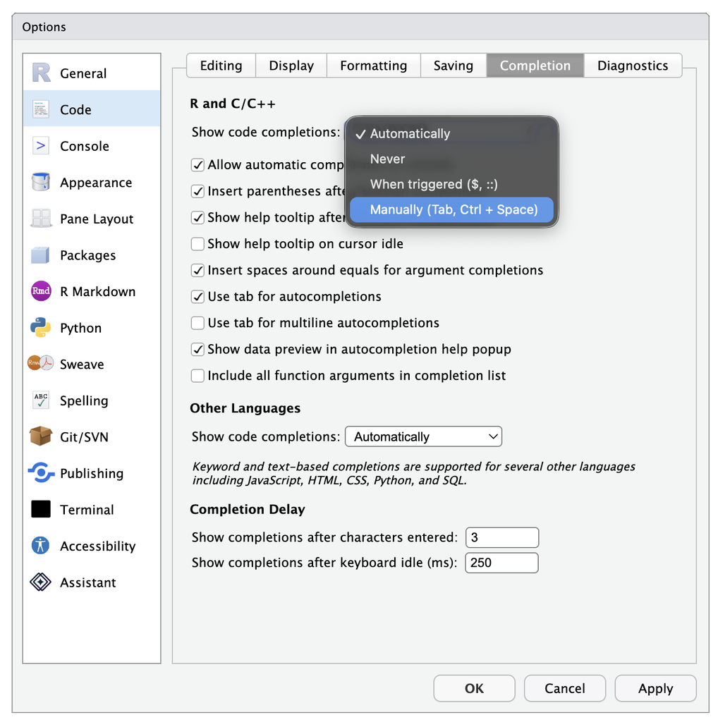

Autocomplete settings in RStudio

### Code

The primary use case for Copilot is to generate code. Copilot will use the context of the active document to generate suggestions for code that might be useful.

Copilot suggestions will be presented as grey ghost text which may be accepted by pressing the Tab, while the Enter/Return key will ignore the suggestion. Some suggestions will be a single entire line, inline of other code, or others with broader context may span multiple lines.

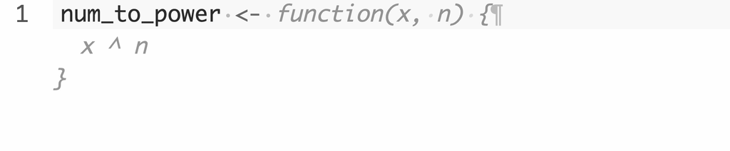

Copilot ghost text

Code suggestions are typically most useful when applied to a well-scoped and specific problem. When trying to solve larger problems or write longer functions, it is best to break the problem down into smaller pieces and use Copilot and your own expertise to generate code for each chunk. Similar to how a chef might use a recipe to cook each dish that makes up a larger meal, Copilot can be used to generate code for smaller pieces of a larger problem.

There are upper limits to the amount of characters or code that can be returned at any one time, commonly referred to as token’s . If the token limit is exceeded on a suggestion, Copilot will usually return a truncated suggestion. This is most common when Copilot is used to generate code for a long function or other multi-line code block. To avoid truncated outputs, it is best to scope the problem down into several smaller prompts or problems. Alternatively, after accepting the partial response, you could finish writing the rest of the code yourself or add additional inline comments to prompt Copilot to suggest additional outputs to complete the remainder of the code snippet.

### Questions

While Copilot is primarily intended to generate code, it can also be used to directly answer simple questions. To specifically ask a question of Copilot, use a comment with a `# q:` at the beginning and a question mark at the end. Copilot’s completion should be an answer comment `# a:`.

For example, the below:

```r
# q: What is the definition of standard error?
```

Might generate an answer like:

```r
# q: What is the definition of standard error?
# a: The standard error is the standard deviation of the sampling distribution of a statistic.
```

> **NOTE:**

> Copilot is most effective when used to generate code, so it is best to use purpose-built generative AI interfaces for chat, such as the [`{chattr}` R package](https://mlverse.github.io/chattr/) which is an R interface to local or remote LLMs (Large Language Models). `{chattr}` includes a RStudio add-in as well as a built in app for interacting with LLMs via RStudios Viewer Pane.

### Comments

When using Copilot to solve a broad problem, it is a good idea to provide a high-level goal at the beginning of the file. This will help Copilot provide suggestions that are relevant to the specific problem you are trying to solve.

```r
# This script will do x
# using the packages x,y,z
# other constraints or details
```

A real example might be:

```r
# Create a robust function to calculate the standard error of a vector
# The function name will be calc_se with an argument x for the vector, with
# an argument to remove missing values called na.rm, and a default value of TRUE
# The function should have type checking to only allow numeric vectors
```

Which might generate something like the below:

```r
calc_se <- function(x, na.rm = TRUE) {
  if (!is.numeric(x)) {
    stop("x must be numeric")
  }
  if (na.rm) {
    x <- x[!is.na(x)]
  }
  sqrt(var(x) / length(x))
}
```

Which generated a working example!

```r
calc_se(1:10)
```

```
#> [1] 0.9574
```

```r
# note the function also properly indicates the need for a numeric input
calc_se(letters)
```

```
#> Error in calc_se(letters) : x must be numeric
```

For smaller problems or to provide context or guidance within a function or code block, comments can be used to provide a basic prompt for Copilot.

Comments in code such as:

```r
# create a function that takes a number and returns the square
```

Might be used by Copilot to suggest a function that takes a number and returns the square:

```r
# create a function that takes a number and returns the square
square_number <- function(x) {
  x^2
}
```

Lastly, comments can be used inline within code to provide additional context or guidance to Copilot. For example:

```r
library(dplyr)

mtcars |>
   group_by(cyl) |>
   summarize(
      mean = mean(mpg),
      # add the standard error for mpg
   )
```

Might return:

```r
mtcars |>
   group_by(cyl) |>
   summarize(
      mean = mean(mpg),
      # add the standard error for mpg
      se = sd(mpg) / sqrt(n())
   )
```

However, the comment may not be needed if a descriptive column name is used instead.

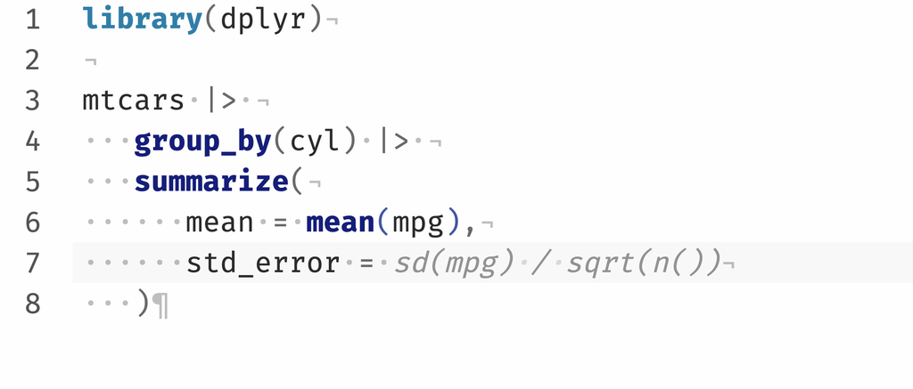

Copilot inline completion

## Disabling GitHub Copilot

To disable GitHub Copilot either:

- Navigate to Tools > Global Options > Assistant and select a different option in the Use code assistant dropdown, or
- Use the Command Palette `Cmd+Shift+P` on Mac or `Ctrl+Shift+P` on Windows/Linux, search for AI Assistant and then select a different option.

## Risks and Best Practices

Copilot can suggest code that looks right and runs without errors while answering the wrong question.

For example, in the standard-error exercise a suggestion can correctly drop missing values when calculating the standard deviation but still count those rows in the denominator. That produces a plausible number that understates the standard error.

Accepting whole solutions can also leave you with code you struggle to explain, debug, or adapt later.

**Key-point**: Stay in the driver’s seat. Set the goal, use Copilot to suggest a small next step, and decide what to keep.

- **Predict before you run.** Work out the expected result for a small example, then compare it with the code’s output. Try an edge case, such as a group with a missing value or just one observation.
- **Understand what you keep.** Read each suggestion and explain what it does in your own words. If you’re unsure about a function or argument, check its R help page and try it on a small example.
- **Protect sensitive information.** Use course practice data. Keep passwords, API keys, identifiable records, and unpublished lab data out of files you use with Copilot.
- **Disclose and verify.** Follow the [course AI policy](https://bioboot.github.io/bimm143_F26/ethics/). Briefly note what the tool helped you with and how you checked the result.

## Practice: Calculate GC content with Copilot.

**Important**Q.** Write an R function called `gc_content()` with the help of GitHub Copilot.**

Your function should take **one input**, a DNA sequence supplied as a single string, and return the **percentage of bases that are G or C** as a number.

For example, `gc_content("ATGC")` should return `50`. Your function should accept both uppercase and lowercase letters.

#### Step 1. Specify the task

In a new R script in RStudio, enable Copilot and write a comment describing what the function should do. You can include the function name to and press Enter and see what Copilot suggests.

#### Step 2. Review the suggestion

Read the suggested code line by line and “steer/guide” copilot in the direction you want to go.

If you’re unsure what an R function does that it suggests, look it up with `?function_name` in the console. Edit the code or refine your comment if the suggestion misses part of your specification.

#### Step 3. Predict, test and refine

Calculate the expected result by hand for each sequence before running the code. If a result differs from your prediction, find the cause, revise the function, and rerun all four tests. Will your function work with the input `"AtgC"`?

```r
gc_content("AAAA")
gc_content("GCCG")
gc_content("AtgC")
gc_content("AATGC")
```

#### Step 4. Document your work

Include your function, your test results, and two or three sentences describing how you used Copilot, if at all, and how you verified the result. If you changed a suggestion, explain what you changed and why.

## About this document

GitHub Copilot was used to help add figures to this lab, draft their alt text, and develop the examples. Here we use the `sessionInfo()` function to report on our R systems setup at the time of document execution.

[session information not shown]